# Pronóstico para serie de tiempo de demanda total de una red espacial

Aarón Ortiz Mendoza

# Motivos

Buscando aplicar las técnicas de pronóstico **Box-Jenkins** a una serie de tiempo de una red espacio-temporal para conocer sus condiciones respecto al tipo de serie **ARIMA**. Se hara un prónostico a una serie de tiempo de la demanda total semanal del grafo.

# Problématica

Se trabaja con un tipo de dato de una red espacial, para el dataset espacio-temporal de las entregas semanales de la aplicación **PedalMe** en Londres, conteniendo una lista de vértices ponderada y una serie de tiempo de las demandas semanales del 2020 al 2021 por nodo. Se busca pronosticar la demanda total semanal de todos los nodos.

# Paquetes

LIbrearías a instalar y utilizadas para realizar el pronóstico.

```r
packages <- c(
  "dplyr", "tidyr", "lubridate", "igraph",
  "feasts", "ggplot2", "tsibble", "tseries", "forecast"
)

# Ver qué paquetes NO están instalados
missing_packages <- setdiff(packages, rownames(installed.packages()))

# Instalar solo los faltantes
if (length(missing_packages) > 0) {
  install.packages(missing_packages)
}

# Cargar todos los paquetes
invisible(lapply(packages, library, character.only = TRUE))
```

# Análisis de la serie de tiempo de la demanda total semanal

Se genera un un panel de datos la serie de tiempo, tomando en cuenta la fecha de los valores que esta dados por un año y semana del mismo.

```r
panel <- read.csv("pedalme_features.csv") %>%
  mutate(
    date = as.Date(ISOdate(year, 1, 4)) + weeks(week - 1)
  ) %>%
  select(date, year, week, node, demand) %>%
  arrange(date, node)
```

## Serie de tiempo de demanda total semanal

Del panel de datos se toma el total de cada semana de las demandas para tener el total semanal.

```r
network_weekly <- panel %>%
  group_by(date) %>%
  summarise(total_demand = sum(demand), .groups = "drop") %>%
  arrange(date)

knitr::kable(head(network_weekly, 10),
             caption = "Demanda total por semana")
```

Demanda total por semana

| date | total_demand |
| --- | --- |
| 2020-05-30 | 22 |
| 2020-06-06 | 315 |
| 2020-06-13 | 317 |
| 2020-06-20 | 337 |
| 2020-06-27 | 392 |
| 2020-07-04 | 385 |
| 2020-07-11 | 424 |
| 2020-07-18 | 439 |
| 2020-07-25 | 427 |
| 2020-08-01 | 481 |

Ahora los transformamos a un objeto de serie de tiempo para poder trabajar con el mismo.

```r
network_ts <- network_weekly %>%
  as_tsibble(index = date)
network_ts <- network_ts %>%
  mutate(week = isoweek(date))
knitr::kable(head(network_ts,20),
             caption = "Demanda total por semana serie de tiempo")
```

Demanda total por semana serie de tiempo

| date | total_demand | week |
| --- | --- | --- |
| 2020-05-30 | 22 | 22 |
| 2020-06-06 | 315 | 23 |
| 2020-06-13 | 317 | 24 |
| 2020-06-20 | 337 | 25 |
| 2020-06-27 | 392 | 26 |
| 2020-07-04 | 385 | 27 |
| 2020-07-11 | 424 | 28 |
| 2020-07-18 | 439 | 29 |
| 2020-07-25 | 427 | 30 |
| 2020-08-01 | 481 | 31 |
| 2020-08-08 | 506 | 32 |
| 2020-08-15 | 365 | 33 |
| 2020-08-22 | 450 | 34 |
| 2020-08-29 | 368 | 35 |
| 2020-09-05 | 504 | 36 |
| 2020-09-12 | 479 | 37 |
| 2020-09-19 | 586 | 38 |
| 2020-09-26 | 497 | 39 |
| 2020-10-03 | 486 | 40 |
| 2020-10-10 | 585 | 41 |

## Análisis de serie de Tiempo de demanda total

**Grafricamos** nuesta serie de tiempo para conocer la misma y sus tendencias.

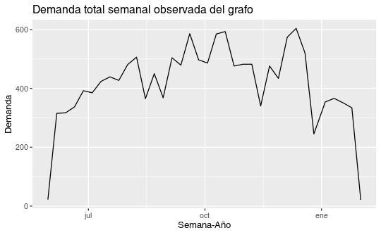

```r
autoplot(network_ts, total_demand) +
  labs(
    title = "Demanda total semanal observada del grafo",
    x="Semana-Año",
    y = "Demanda"
  )
```

Se acaba realizando una diagnóstico de la serie para conocer los los parámetros a considerar del modelo *ARIMA* del método Box-Jenkins, donde queremos revisar los parámetros: * Autoregresión *P* * Integración *I* * Media Movíl *Q*

Además de realizar una prueba **aumentada de Dickey-Fuller** para conocer si la serie es estacionaria o se necesitara realizar una diferencia para volverla una. Además de las gráficas de las funciones de autoregresión y autroregresión parcial para saber que paramétros ir considerando para el modelo **ARIMA**.

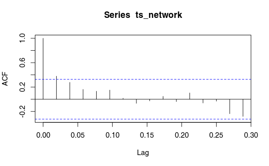

```r
ts_network <- ts(
  network_weekly$total_demand,
  frequency = 52
)

acf_plot<-acf(ts_network, lag.max = 15)
```

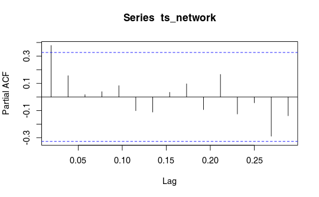

```r
pacf_plot<-pacf(ts_network, lag.max = 15)
```

```r
adf.test(ts_network)
```

```
    Augmented Dickey-Fuller Test

data:  ts_network
Dickey-Fuller = -0.72887, Lag order = 3, p-value = 0.9584
alternative hypothesis: stationary
```

Vemos que la serie debe diferenciarse así que los en base a tener las diferencias entre el valor actual y sus lags.

```r
# Diferenciación
d_total <- diff(ts_network)
```

Realizamos de nuevo la prueba **aumentada de Dickey-Fuller** para revisar la estacionalidad como revisar de nuevo las funciones de autoregresión y autoregresión parcial para conocer los paramétros del modelo **ARIMA** siguiendo la metología **Box-Jenkins**.

```r
adf.test(d_total)
```

```
    Augmented Dickey-Fuller Test

data:  d_total
Dickey-Fuller = -4.5376, Lag order = 3, p-value = 0.01
alternative hypothesis: stationary
```

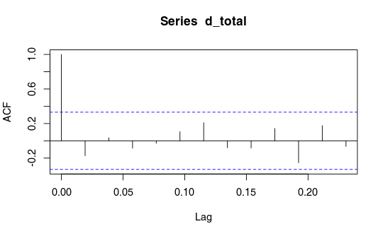

```r
acf_dtotal<-acf(d_total, lag.max = 12)
```

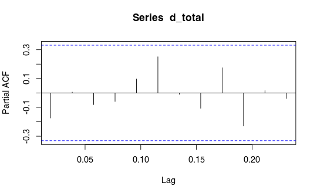

```r
pacdf_dtotal<-pacf(d_total, lag.max = 12)
```

Divideremos en la serie en un 80% para los datos de entrenamiento y el 20% para la prueba para podre ir seleccionando el modelo a escoger en base a lo visto, de la preuba **aumentada de Dickey-Fuller**, función de autoregresión y autoregresión parcial para ir tomando en cuenta que modelo aplicar en base a los parámetros.

```r
n <- length(ts_network)
n_train <- floor(0.8 * n)

train_total <- window(ts_network, end = c(1, n_train))
test_total  <- window(ts_network, start = c(1, n_train + 1))
```

Probamos tres modelos distintos con los parámetros de: * I(1) y MA(1) * AR(1) y I(1) * AR(1), I(1) y MA(1)

```r
# Demanda total
m1_total <- Arima(train_total, order = c(0,1,1))
m2_total <- Arima(train_total, order = c(1,1,0))
m3_total <- Arima(train_total, order = c(1,1,1))
```

```r
h <- length(test_total)

fc_total_011 <- forecast(m1_total, h = h)
fc_total_110 <- forecast(m2_total, h = h)
fc_total_111 <- forecast(m3_total, h = h)
```

Revisaremos los residuos en base a la preuba Ljung-Box para considerar si alguno de los tres propuestos es mejor a los demás en base a su autoregresión.

```
    Ljung-Box test

data:  Residuals from ARIMA(0,1,1)
Q* = 1.2749, df = 5, p-value = 0.9375

Model df: 1.   Total lags used: 6
```

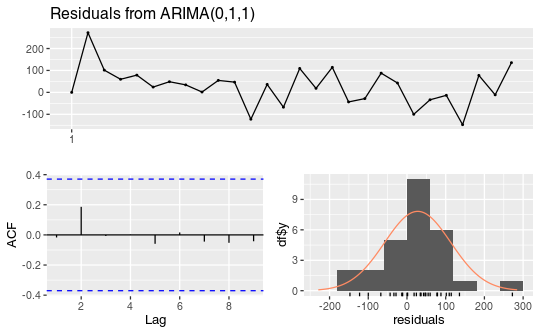

```r
checkresiduals(m1_total)
```

```
    Ljung-Box test

data:  Residuals from ARIMA(1,1,0)
Q* = 0.61194, df = 5, p-value = 0.9874

Model df: 1.   Total lags used: 6
```

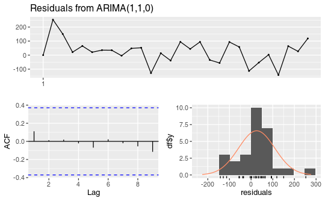

```r
checkresiduals(m2_total)
```

```
    Ljung-Box test

data:  Residuals from ARIMA(1,1,1)
Q* = 0.53295, df = 4, p-value = 0.9702

Model df: 2.   Total lags used: 6
```

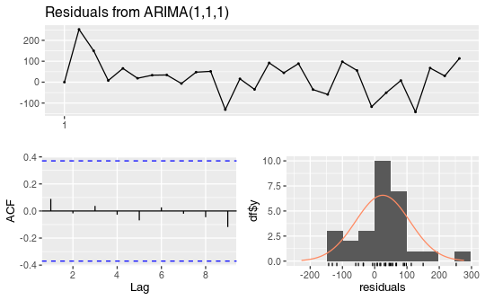

```r
checkresiduals(m3_total)
```

```r
AIC(m1_total, m2_total, m3_total)
```

|  | df | AIC |
| --- | --- | --- |
| m1_total | 2 | 323.8772 |
| m2_total | 2 | 322.5759 |
| m3_total | 3 | 324.5351 |

Tomaremos las medidas en base a los datos de prueba la factibilidad de considerar en base a diferentes criterios de errores.

```r
accuracy(fc_total_011, test_total)
```

```
                     ME      RMSE       MAE         MPE      MAPE MASE        ACF1
Training set   27.74776  88.53014  68.28339    6.249306  16.47685  NaN -0.01674025
Test set     -170.73890 236.22607 191.71043 -333.511691 336.98380  NaN  0.14202740
             Theil's U
Training set        NA
Test set      1.627661
```

```r
accuracy(fc_total_110, test_total)
```

```
                     ME      RMSE       MAE         MPE      MAPE MASE      ACF1
Training set   25.72814  86.22295  66.49755    5.875975  16.00865  NaN 0.1110011
Test set     -175.57171 241.72151 200.80674 -338.857622 343.03561  NaN 0.1505220
             Theil's U
Training set        NA
Test set      1.666014
```

```r
accuracy(fc_total_111, test_total)
```

```
                     ME      RMSE       MAE         MPE      MAPE MASE       ACF1
Training set   24.93282  86.15284  66.18857    5.675558  15.91267  NaN 0.08913092
Test set     -178.09026 243.53615 203.09229 -341.107202 345.24661  NaN 0.15113860
             Theil's U
Training set        NA
Test set      1.681415
```

```r
ts_total_log <- log1p(ts_network)
# Modelo ya ajustado
model_log <- Arima(ts_total_log, order = c(0,1,1))

# Pronóstico
fc_log <- forecast(model_log, h = 10, level = c(80, 95))

# Media
mean_fc <- expm1(fc_log$mean)

# Intervalos
lower80 <- expm1(fc_log$lower[, "80%"])
upper80 <- expm1(fc_log$upper[, "80%"])

lower95 <- expm1(fc_log$lower[, "95%"])
upper95 <- expm1(fc_log$upper[, "95%"])
```

Tranformando igualemente los datos para poder tener una orden crónologico como la serie de tiempo original para poder tener una coherencia en nuestra serie de tiempo.

```r
future_dates <- seq(
  from = max(network_weekly$date) + weeks(1),
  by = "week",
  length.out = length(mean_fc)
)
fc_df <- data.frame(
  date = future_dates,
  mean = as.numeric(mean_fc),
  lower80 = as.numeric(lower80),
  upper80 = as.numeric(upper80),
  lower95 = as.numeric(lower95),
  upper95 = as.numeric(upper95)
)
```

## Gráfica del pronóstico final de la serie de tiempo de la red espacial

Gráfica con los valores presentados de la serie de tiempo de la demanda total semanal de nuesta red espacial.

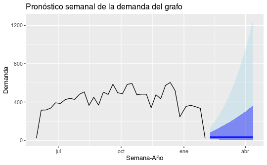

```r
ggplot() +
  geom_line(
    data = network_weekly,
    aes(x = date, y = total_demand),
    color = "black"
  ) +
  geom_ribbon(
    data = fc_df,
    aes(x = date, ymin = lower95, ymax = upper95),
    fill = "lightblue",
    alpha = 0.4
  ) +
  geom_ribbon(
    data = fc_df,
    aes(x = date, ymin = lower80, ymax = upper80),
    fill = "blue",
    alpha = 0.4
  ) +
  geom_line(
    data = fc_df,
    aes(x = date, y = mean),
    color = "blue",
    linewidth = 1
  ) +
  labs(
    title = "Pronóstico semanal de la demanda del grafo",
    x = "Semana-Año",
    y = "Demanda"
  )
```

# Extra-Análisis de grafo ponderado

## Grafo Completo Ponderado

- Matriz de adyaciencia ente los nodos con su ponderación
- Gráfica de conexión entre los nodos con sus vértices en base a su ponderación

```r
edges <- read.csv("pedalme_edges.csv")

g <- graph_from_data_frame(edges, directed = FALSE)
E(g)$weight <- edges$weight

matriz_adyacencia <- as.matrix(
  as_adjacency_matrix(g, attr = "weight", sparse = FALSE)
)
diag(matriz_adyacencia) <- 0
```

## Histograma de ponderaciones del grafo

Se muestra la frecuencia de los valores ponderados de los vértices entre los nodos, dado que en la red se conectan los nodos con todos los de la misma red, se considera al grafo uno completo, los valores de uno son los de los nodos conectados consigo mismos. Además de uns resumen de los valores de las ponderaciones de los vértices de la red.

```r
summary(E(g)$weight)
```

```
    Min.  1st Qu.   Median     Mean  3rd Qu.     Max.
0.007879 0.120345 0.224675 0.287179 0.382945 1.000000
```

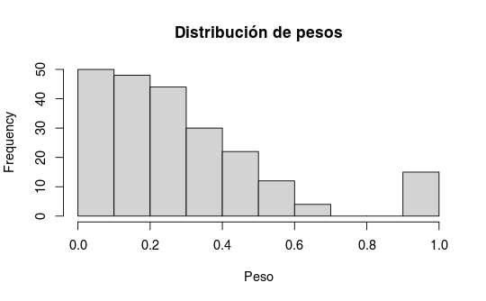

```r
hist(E(g)$weight, main = "Distribución de pesos", xlab = "Peso")
```

## Mapa de calor del grafo completo ponderado

Como en el caso anterior se muestra en base a un color más oscruro a claro, llendo de un valor entre 0 a 1 de los vértices ponderados entre los vértices.

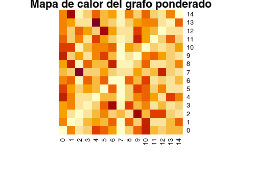

```r
heatmap(matriz_adyacencia,
        Rowv = NA, Colv = NA,
        scale="row",
        main = "Mapa de calor del grafo ponderado")
```

## Dimensiones del grafo

Dimensiones de la matriz de adayaciencia además de los valores de las conexiones entre los nodos a través de la lista de vértices.

```r
# Dimensiones y estructura
dim(edges)
```

```
[1] 225   3
```

```r
str(edges)
```

```
'data.frame':   225 obs. of  3 variables:
 $ from  : int  0 0 0 0 0 0 0 0 0 0 ...
 $ to    : int  0 1 2 3 4 5 6 7 8 9 ...
 $ weight: num  1 0.425 0.157 0.207 0.564 ...
```

```r
# Primeras filas
knitr::kable(head(edges, 10),
             caption = "Lista de vértices ponderados del grafo")
```

Lista de vértices ponderados del grafo

| from | to | weight |
| --- | --- | --- |
| 0 | 0 | 1.0000000 |
| 0 | 1 | 0.4254590 |
| 0 | 2 | 0.1573554 |
| 0 | 3 | 0.2065002 |
| 0 | 4 | 0.5641481 |
| 0 | 5 | 0.5185980 |
| 0 | 6 | 0.4004257 |
| 0 | 7 | 0.0266818 |
| 0 | 8 | 0.2246753 |
| 0 | 9 | 0.5012188 |

## Gráfica del grafo con pesos

Gráfica de toda la red donde se presenta los nodos y vértices, donde los pesos se representan a través del grosor del vértice que conecta los nodos.

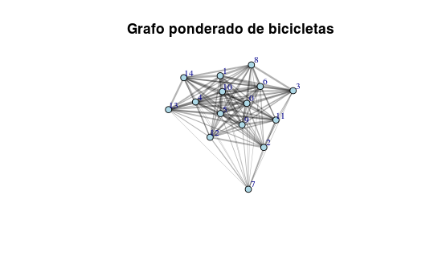

```r
# Crear grafo
g <- graph_from_adjacency_matrix(matriz_adyacencia, mode = "undirected", weighted = TRUE)

layout_fr <- layout_with_fr(g, weights = E(g)$weight)

plot(g,
     layout = layout_fr,
     vertex.size = 10,
     vertex.color = "lightblue",
     vertex.label.dist = 1.5,
     vertex.label.cex = 0.8,
     vertex.label.color = "darkblue",
     edge.width = sqrt(E(g)$weight) * 3,
     edge.color = rgb(0,0,0,0.3),
     main = "Grafo ponderado de bicicletas")
```

# Referencias

GeeksforGeeks. 2025. “Box-Jenkins Methodology for ARIMA Models.” https://www.geeksforgeeks.org/machine-learning/box-jenkins-methodology-for-arima-models/.

Moffatt, Mike. 2024. “An Introduction to Akaike’s Information Criterion (AIC).” https://www.thoughtco.com/introduction-to-akaikes-information-criterion-1145956.

Rozemberczki, Benedek, Paul Scherer, Yixuan He, George Panagopoulos, Alexander Riedel, Maria Astefanoaei, Oliver Kiss, et al. 2021. “PyTorch Geometric Temporal: Spatiotemporal Signal Processing with Neural Machine Learning Models.” In *Proceedings of the 30th ACM International Conference on Information and Knowledge Management*.

Scott, Gordon. 2025. “Box-Jenkins Model Explained: Uses, Methodology, and Forecasting.” https://www.investopedia.com/terms/b/box-jenkins-model.asp.